# Heart Disease: Predicting Presence of Heart Disease

# Reading the file

```r
disease <- read.csv("/Users/Esteban/Downloads/heartdisease1.csv")
attach(disease)
```

# Data Cleaning

```r
sapply(disease, typeof)
```

```
##          age          sex           cp     trestbps         chol          fbs
##    "integer"    "integer"    "integer"    "integer"    "integer"    "integer"
##      restecg      thalach        exang      oldpeak        slope           ca
##    "integer"    "integer"    "integer"     "double"    "integer"    "integer"
##         thal heartdisease
##    "integer"    "integer"
```

We know from the UCI Machine Learning Repository that in the data set features 1, 4, 5, 8, and 10 are numerical. We will keep the values as is, as some of them like age for example, are supposed to be integers and not doubles.

## Quantitative Data

We will now replace the “NA” values with the mean imputation of each feature.

```r
disease$age[is.na(disease$age)] <- mean(disease$age,na.rm=TRUE) # 1
disease$trestbps[is.na(disease$trestbps)] <- mean(disease$trestbps,na.rm=TRUE) # 4
disease$chol[is.na(disease$chol)] <- mean(disease$chol,na.rm=TRUE) # 5
disease$thalach[is.na(disease$thalach)] <- mean(disease$thalach,na.rm=TRUE) # 8
disease$oldpeak[is.na(disease$oldpeak)] <- mean(disease$oldpeak,na.rm=TRUE) # 10
```

```r
ind <- c(1,4,5,8,10)

for (i in ind){
  print(anyNA(disease[,i]))
}
```

```
## [1] FALSE
## [1] FALSE
## [1] FALSE
## [1] FALSE
## [1] FALSE
```

## Qualitative Data

We know from the UCI Machine Learning Repository that 3, 7, 11, 12, 13, and 14 are categorical features. We also know that 2, 6, 9, and 14 are supposed to be binary.

First we want to remove any NA qualitative observations.

```r
dim(na.omit(disease))
```

```
## [1] 145  14
```

```r
disease <- na.omit(disease)
```

Notice that the amount of observations decreased significantly.

Now we will turn the qualitative features into factors, in R we do not need to perform OHE (One Hot Encoding) if we do this.

```r
ind <- c(2,3,6,7,9,11,12,13,14)

for (i in ind){
  disease[,i] <- as.factor(disease[,i])
  print(levels(disease[,i]))
}
```

```
## [1] "0" "1"
## [1] "1" "2" "3" "4"
## [1] "0" "1"
## [1] "0" "1" "2"
## [1] "0" "1"
## [1] "1" "2" "3"
## [1] "0" "1" "2" "3"
## [1] "3" "6" "7"
## [1] "0" "1"
```

```r
colnames(disease[,sapply(disease,is.factor)])
```

```
## [1] "sex"          "cp"           "fbs"          "restecg"      "exang"
## [6] "slope"        "ca"           "thal"         "heartdisease"
```

# Exploratory Data Analysis for Quantitative Variables

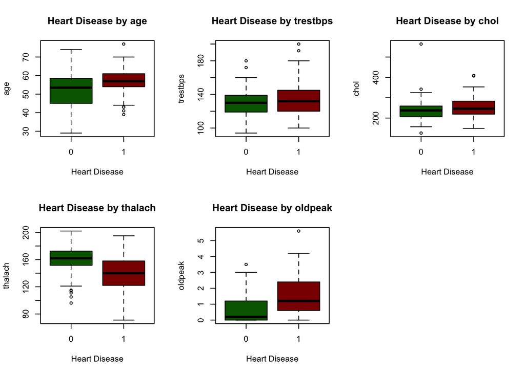

```r
par(mfrow = c(2,3))
boxplot(age~heartdisease, data = disease, col = c("darkgreen", "darkred"), main = "Heart Disease by age", xlab = "Heart Disease")
boxplot(trestbps~heartdisease, data = disease, col = c("darkgreen", "darkred"), main = "Heart Disease by trestbps", xlab= "Heart Disease") # Kinda different
boxplot(chol~heartdisease, data = disease, col = c("darkgreen", "darkred"), main = "Heart Disease by chol", xlab = "Heart Disease") # Not very different
boxplot(thalach~heartdisease, data = disease, col = c("darkgreen", "darkred"), main = "Heart Disease by thalach", xlab= "Heart Disease")
boxplot(oldpeak~heartdisease, data = disease, col = c("darkgreen", "darkred"), main = "Heart Disease by oldpeak", xlab = "Heart Disease")
```

# Qualitative Visualization

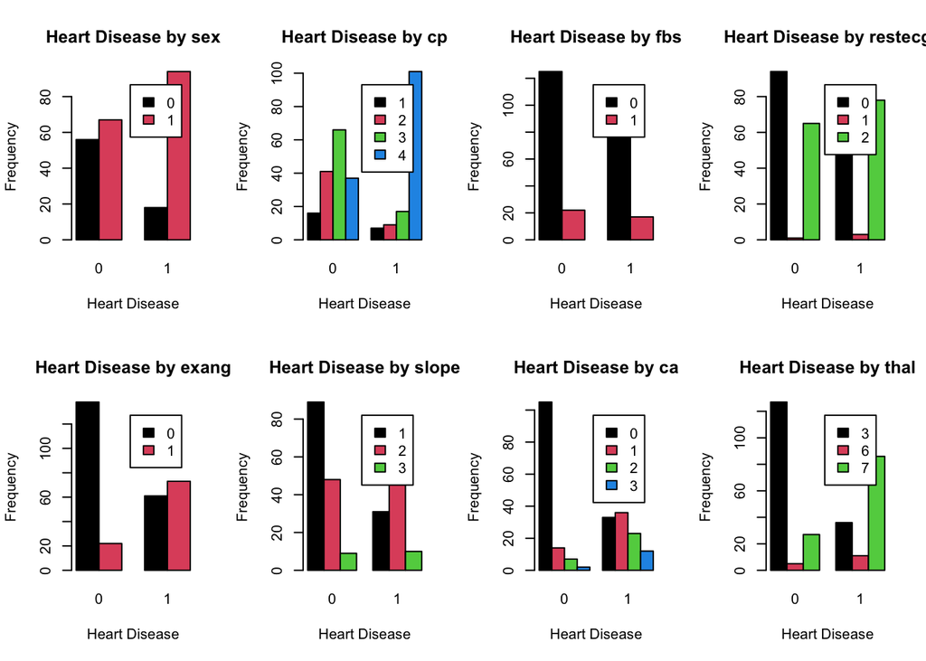

```r
par(mfrow = c(2, 4))
barplot(table(sex, heartdisease), legend.text = T, beside = T, main = "Heart Disease by sex", ylab = "Frequency", xlab = "Heart Disease", col = 1:2) # Sex

barplot(table(cp, heartdisease), legend.text = T, beside = T, main = "Heart Disease by cp", ylab = "Frequency", xlab = "Heart Disease", col = 1:4) # cp

barplot(table(fbs, heartdisease), legend.text = T, beside = T, main = "Heart Disease by fbs", ylab = "Frequency", xlab = "Heart Disease", col = 1:2) #fbs

barplot(table(restecg, heartdisease), legend.text = T, beside = T, main = "Heart Disease by restecg", ylab = "Frequency", xlab = "Heart Disease", col = 1:3) # restecg

barplot(table(exang, heartdisease), legend.text = T, beside = T, main = "Heart Disease by exang", ylab = "Frequency", xlab = "Heart Disease", col = 1:2) # exang

barplot(table(slope, heartdisease), legend.text = T, beside = T, main = "Heart Disease by slope", ylab = "Frequency", xlab = "Heart Disease", col = 1:3) # slope

barplot(table(ca, heartdisease), legend.text = T, beside = T, main = "Heart Disease by ca", ylab = "Frequency", xlab = "Heart Disease", col= 1:4) # ca

barplot(table(thal, heartdisease), legend.text = T, beside = T, main = "Heart Disease by thal", ylab = "Frequency", xlab = "Heart Disease", col = 1:3) # thal
```

Now split the data into training and testing sets, using a 70-30 split.

```r
set.seed(4052)
test.ind <- sample(nrow(disease), floor(nrow(disease)*0.3))

train <- disease[-test.ind,]
test <- disease[test.ind,]
```

# Logistic Regression (Mean Imputation)

```r
set.seed(1)
log.model <- glm(heartdisease~., data = train, family = binomial)
summary(log.model)
```

```
##
## Call:
## glm(formula = heartdisease ~ ., family = binomial, data = train)
##
## Deviance Residuals:
##     Min       1Q   Median       3Q      Max
## -1.9238  -0.4515  -0.0477   0.2809   2.4332
##
## Coefficients:
##               Estimate Std. Error z value Pr(>|z|)
## (Intercept) -1.915e+00  5.455e+00  -0.351   0.7255
## age         -1.343e-02  5.491e-02  -0.245   0.8068
## sex1         3.058e+00  1.295e+00   2.361   0.0182 *
## cp2          2.120e+00  1.669e+00   1.270   0.2040
## cp3          1.619e+00  1.717e+00   0.943   0.3455
## cp4          3.862e+00  1.756e+00   2.199   0.0279 *
## trestbps     1.607e-02  2.204e-02   0.729   0.4658
## chol         6.028e-03  6.900e-03   0.874   0.3823
## fbs1        -7.178e-01  1.061e+00  -0.676   0.4988
## restecg1     1.815e+01  2.400e+03   0.008   0.9940
## restecg2     2.328e+00  1.063e+00   2.190   0.0285 *
## thalach     -5.407e-02  2.315e-02  -2.336   0.0195 *
## exang1      -1.447e+00  1.114e+00  -1.298   0.1942
## oldpeak      7.616e-01  5.231e-01   1.456   0.1454
## slope2      -2.278e+00  1.435e+00  -1.588   0.1124
## slope3       2.529e-01  1.987e+00   0.127   0.8987
## ca1          1.117e+00  1.133e+00   0.986   0.3242
## ca2          5.243e+00  2.058e+00   2.547   0.0109 *
## ca3          9.924e-01  1.408e+00   0.705   0.4808
## thal6        5.508e-01  1.866e+00   0.295   0.7678
## thal7        2.024e+00  1.070e+00   1.890   0.0587 .
## ---
## Signif. codes:  0 '***' 0.001 '**' 0.01 '*' 0.05 '.' 0.1 ' ' 1
##
## (Dispersion parameter for binomial family taken to be 1)
##
##     Null deviance: 140.42  on 101  degrees of freedom
## Residual deviance:  57.60  on  81  degrees of freedom
## AIC: 99.6
##
## Number of Fisher Scoring iterations: 15
```

Perform stepwise function moving backwards to remove feature, this helps with overfitting by making a simpler model.

```r
MASS::stepAIC(log.model, direction = "backward")
```

```
## Start:  AIC=99.6
## heartdisease ~ age + sex + cp + trestbps + chol + fbs + restecg +
##     thalach + exang + oldpeak + slope + ca + thal
##
##            Df Deviance     AIC
## - age       1   57.660  97.660
## - fbs       1   58.073  98.073
## - trestbps  1   58.156  98.156
## - chol      1   58.332  98.332
## - exang     1   59.513  99.513
## <none>          57.600  99.600
## - oldpeak   1   59.985  99.985
## - thal      2   62.358 100.358
## - slope     2   62.439 100.439
## - cp        3   66.142 102.142
## - restecg   2   64.726 102.726
## - sex       1   64.784 104.784
## - thalach   1   64.915 104.915
## - ca        3   69.163 105.163
##
## Step:  AIC=97.66
## heartdisease ~ sex + cp + trestbps + chol + fbs + restecg + thalach +
##     exang + oldpeak + slope + ca + thal
##
##            Df Deviance     AIC
## - fbs       1   58.102  96.102
## - trestbps  1   58.172  96.172
## - chol      1   58.341  96.341
## <none>          57.660  97.660
## - exang     1   59.745  97.745
## - slope     2   62.698  98.698
## - oldpeak   1   60.869  98.869
## - thal      2   63.115  99.115
## - restecg   2   64.735 100.735
## - cp        3   67.344 101.344
## - thalach   1   65.329 103.329
## - sex       1   65.378 103.378
## - ca        3   71.037 105.037
##
## Step:  AIC=96.1
```

[output cut: 34 more lines]

```
## Step:  AIC=93.51
## heartdisease ~ sex + cp + restecg + thalach + exang + oldpeak +
##     slope + ca + thal
##
##           Df Deviance     AIC
## <none>         59.512  93.512
## - slope    2   64.260  94.260
## - exang    1   62.304  94.304
## - oldpeak  1   62.911  94.911
## - thal     2   65.709  95.709
## - restecg  2   66.965  96.965
## - cp       3   70.937  98.937
## - sex      1   66.965  98.965
## - thalach  1   67.011  99.011
## - ca       3   74.324 102.324
```

```
##
## Call:  glm(formula = heartdisease ~ sex + cp + restecg + thalach + exang +
##     oldpeak + slope + ca + thal, family = binomial, data = train)
##
## Coefficients:
## (Intercept)         sex1          cp2          cp3          cp4     restecg1
##     0.47221      2.77026      1.99420      1.25468      3.90170     17.69813
##    restecg2      thalach       exang1      oldpeak       slope2       slope3
##     2.35695     -0.04976     -1.70369      0.80791     -2.19233      0.02668
##         ca1          ca2          ca3        thal6        thal7
##     1.24622      5.08936      0.95520      0.05864      1.99733
##
## Degrees of Freedom: 101 Total (i.e. Null);  85 Residual
## Null Deviance:       140.4
## Residual Deviance: 59.51     AIC: 93.51
```

Now that we can build the training model removing the unnecessary features.

```r
# Final model (Build using training set)
log.model <- glm(heartdisease~. -slope -chol -age -fbs -oldpeak -exang, data = train, family = binomial)
```

We will now build the testing model for logistic regression.

```r
# Predicted probability of being in class
log.pred <- predict(log.model, newdata = test, type = "response")
log.class <- as.numeric(log.pred > 0.5)

# Confusion Matrix
(mat <- xtabs(~log.class + test$heartdisease))
```

```
##          test$heartdisease
## log.class  0  1
##         0 21  3
##         1  3 16
```

```r
# Error rate
(mat[1,2] + mat[2,1])/sum(mat)
```

```
## [1] 0.1395349
```

## ROC curve and AUC

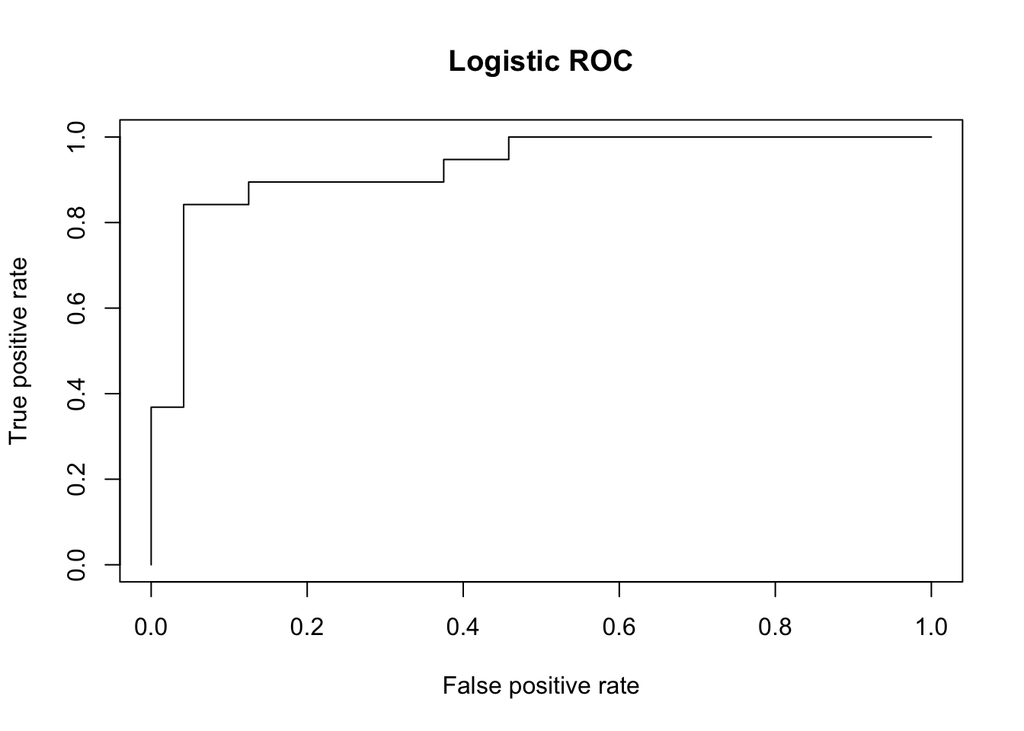

```r
set.seed(1)
log.pred <- predict(log.model, newdata = test)
pred <- prediction(predictions = log.pred, labels = test$heartdisease)

# ROC Curve
log.roc <- performance(pred, measure = "tpr", x.measure = "fpr")
plot(log.roc, main = "Logistic ROC")
```

We can see that the the ROC curve looks pretty good, maybe we could have gotten better results if we performed cross validation instead of a train-test split but for now this is ok.

```r
log_perf2 <- performance(pred, measure = "auc")
log_perf2@y.values[[1]]
```

```
## [1] 0.9298246
```

# Random Forest

We will use k-fold cross validation for the random forest method. For random forest the only hyperparameters we want to tune is the number of trees(ntree), and the number of features to use per split (n).

```r
p <- ncol(train) - 1
k <- 5
ntree <- c(100, 200, 300, 400, 500, 600, 700, 800, 900, 1000)

n <- 1:p
tuningpar <- expand.grid(n, ntree)
cv.er.forest <- matrix(nrow = k, ncol = nrow(tuningpar))
```

## Cross Validation K-Fold Split

```r
set.seed(1)
obs.per.fold <- ceiling(nrow(train)/k)
shuffle.indices <- sample(nrow(train), nrow(train))
folds <- vector("list", length = k)
for (i in 1:k) {
  if (i != k) {
    fold.indices <- (i - 1)*obs.per.fold + 1:obs.per.fold
    folds[[i]] <- shuffle.indices[fold.indices]
  } else {
    fold.indices <- ((i - 1)*obs.per.fold + 1):nrow(train)
    folds[[i]] <- shuffle.indices[fold.indices]
  }
}
```

## Testing for the two hyper parameters, ntrees && mtry.

```r
set.seed(1)
for (i in 1:k) {
  cv.training <- train[-folds[[i]],]
  cv.validation <- train[folds[[i]],]
    for (j in 1:nrow(tuningpar)) {
      rf <- randomForest(x = cv.training[,-11], y = cv.training[,11], mtry = tuningpar[j,1],
      ntree = tuningpar[j,2])
      rfpred <- predict(rf, newdata = cv.validation[,-11])
      cv.er.forest[i,j] <- mean(rfpred != cv.validation[,11])
    }
}
meancv <- colMeans(cv.er.forest)
optimal <- tuningpar[which(meancv == min(meancv)),]
names(optimal) <- c("# of Parameters", "# of Trees")
optimal
```

```
##    # of Parameters # of Trees
## 54               2        500
```

## Building the Model, and Making Predictions

```r
rand.forest <- randomForest(x = train[,-14], y = train[,14], mtry = 2, ntree = 1000)

#Predicted probability of being in class
rand.pred <- predict(rand.forest, newdata = test[,-14], type = "prob")[,2]
```

## Importance

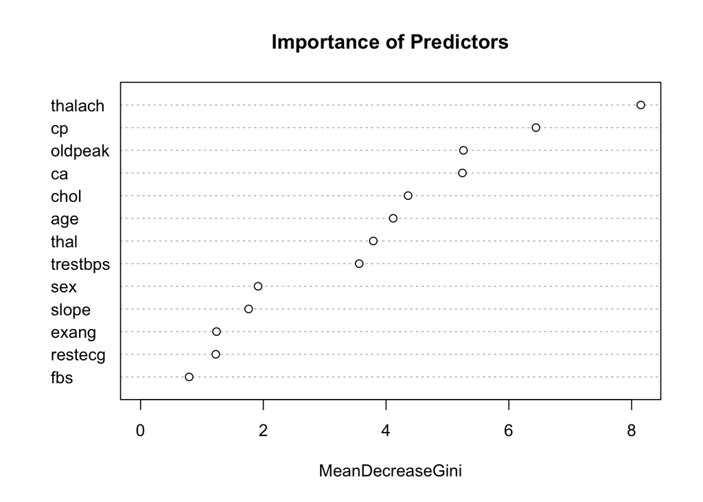

```r
varImpPlot(rand.forest, main = "Importance of Predictors")
```

## Random Forest Confusion Matrix

```r
rand.class <- predict(rand.forest, newdata = test[,-14], type = "response")
(mat <- xtabs(~rand.class + test$heartdisease))
```

```
##           test$heartdisease
## rand.class  0  1
##          0 22  6
##          1  2 13
```

```r
(mat[1,2]+mat[2,1])/sum(mat) # Error rate
```

```
## [1] 0.1860465
```

The test error rate is about 20%

## ROC and AUC Curves

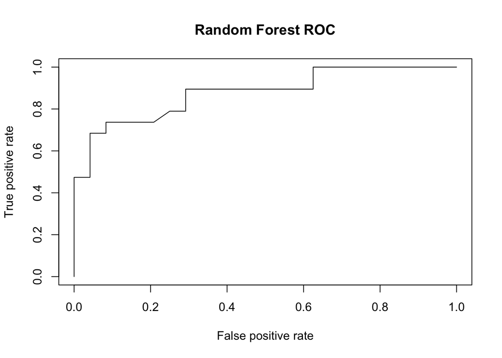

```r
set.seed(1)
pred <- prediction(predictions = rand.pred, labels = test$heartdisease)

rand.roc <- performance(pred, measure = "tpr", x.measure = "fpr")
plot(rand.roc, main = "Random Forest ROC")
```

```r
# AUC for Random Forest
log_perf2 <- performance(pred, measure = "auc")
log_perf2@y.values[[1]]
```

```
## [1] 0.8782895
```

## Support Vector Machine Polynomial Kernel (SVM)

```r
set.seed(1)
tune.out <- tune(svm, heartdisease~., data = train,ranges = list(cost = c(0.001, 0.01, 0.1, 1, 10, 100), degree = c(1,2,3),  kernel = c("linear", "polynomial", "radial")))
summary(tune.out)
```

```
##
## Parameter tuning of 'svm':
##
## - sampling method: 10-fold cross validation
##
## - best parameters:
##  cost degree     kernel
##     1      2 polynomial
##
## - best performance: 0.2263636
##
## - Detailed performance results:
##     cost degree     kernel     error dispersion
## 1  1e-03      1     linear 0.4536364 0.11486807
## 2  1e-02      1     linear 0.2636364 0.11134044
```

[output cut: 52 more lines]

```r
best <- summary(tune.out)$best.model
```

```r
svm.pred <- predict(best, newdata = test)
(mat <- xtabs(~svm.pred + test$heartdisease))
```

```
##         test$heartdisease
## svm.pred  0  1
##        0 23 10
##        1  1  9
```

```r
(mat[1,2] + mat[2,1])/sum(mat)
```

```
## [1] 0.255814
```

## ROC for SVM

```r
#Create the function
rocplot<-function(predi,truth,...){
predob<-prediction(predi,truth)
perf<-performance(predob,"tpr","fpr")
plot(perf,...)
}
```

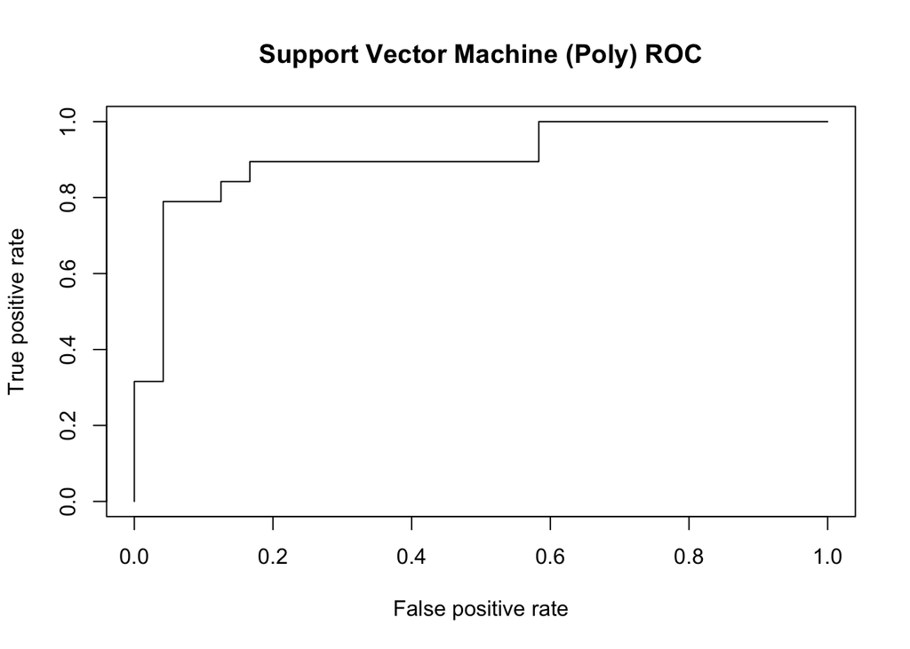

```r
# Obtain the fitted values
svm.fit <- svm(heartdisease~., data = train, kernel = "linear", degree = 1, cost = 10, decision.values=TRUE)
fitted <- attributes(predict(svm.fit, newdata = test, decision.values=TRUE))$decision.values
rocplot(-fitted, test$heartdisease, main = "Support Vector Machine (Poly) ROC")
```

## AUC for SVM

```r
svm.fit <- svm(heartdisease~., data = train, kernel = "linear", degree = 1, cost = 10, probability=TRUE)
prob <- attributes(predict(svm.fit, newdata = test, probability =TRUE))$probabilities[,2]

predictionsvm <- prediction(prob,test$heartdisease)
svm_perf2 <- performance(predictionsvm, measure = "auc")
svm_perf2@y.values[[1]]
```

```
## [1] 0.9035088
```

# Imputation of Data

```r
disease <- read.csv("/Users/Esteban/Downloads/heartdisease1.csv")
```

Check the data

```r
str(disease)
```

```
## 'data.frame':    303 obs. of  14 variables:
##  $ age         : int  63 67 67 37 41 56 62 57 63 53 ...
##  $ sex         : int  1 1 1 1 0 1 0 NA 1 1 ...
##  $ cp          : int  1 4 4 3 2 2 4 4 4 4 ...
##  $ trestbps    : int  145 160 120 130 130 120 140 120 130 140 ...
##  $ chol        : int  233 NA 229 250 204 236 268 354 254 203 ...
##  $ fbs         : int  1 0 0 0 0 0 0 0 NA 1 ...
##  $ restecg     : int  2 2 2 0 2 0 2 0 2 2 ...
##  $ thalach     : int  150 108 129 187 172 178 160 163 147 155 ...
##  $ exang       : int  0 1 1 0 0 0 0 1 0 1 ...
##  $ oldpeak     : num  2.3 1.5 2.6 3.5 1.4 0.8 3.6 0.6 1.4 3.1 ...
##  $ slope       : int  3 2 2 3 1 1 3 NA NA NA ...
##  $ ca          : int  0 3 2 0 0 0 NA 0 1 0 ...
##  $ thal        : int  6 3 7 3 3 3 3 3 7 7 ...
##  $ heartdisease: int  0 1 1 0 0 0 1 0 1 1 ...
```

```r
dim(na.omit(disease))
```

```
## [1] 125  14
```

```r
library(mi)
```

Create a missing data frame

```r
mdf <- missing_data.frame(disease, favor_ordered = FALSE, favor_positive = TRUE)
show(mdf)
```

```
## Object of class missing_data.frame with 303 observations on 14 variables
##
## There are 36 missing data patterns
##
## Append '@patterns' to this missing_data.frame to access the corresponding pattern for every observation or perhaps use table()
##
##                                   type missing method  model
## age                positive-continuous      30    ppd linear
## sex                             binary      60    ppd  logit
## cp               unordered-categorical       0   <NA>   <NA>
## trestbps           positive-continuous       0   <NA>   <NA>
## chol               positive-continuous      30    ppd linear
## fbs                             binary      30    ppd  logit
## restecg          unordered-categorical       0   <NA>   <NA>
## thalach            positive-continuous       0   <NA>   <NA>
## exang                           binary       0   <NA>   <NA>
## oldpeak         nonnegative-continuous       0   <NA>   <NA>
## oldpeak:is_zero                 binary       0   <NA>   <NA>
## slope            unordered-categorical      30    ppd mlogit
## ca               unordered-categorical      63    ppd mlogit
## thal             unordered-categorical       2    ppd mlogit
## heartdisease                    binary       9    ppd  logit
##
##                      family     link transformation
## age                gaussian identity            log
## sex                binomial    logit           <NA>
## cp                     <NA>     <NA>           <NA>
## trestbps               <NA>     <NA>            log
## chol               gaussian identity            log
## fbs                binomial    logit           <NA>
## restecg                <NA>     <NA>           <NA>
## thalach                <NA>     <NA>            log
## exang                  <NA>     <NA>           <NA>
## oldpeak                <NA>     <NA>       logshift
## oldpeak:is_zero        <NA>     <NA>           <NA>
## slope           multinomial    logit           <NA>
## ca              multinomial    logit           <NA>
## thal            multinomial    logit           <NA>
## heartdisease       binomial    logit           <NA>
```

Change the transformations to the identity

```r
mdf <- change(mdf, y = c("age", "trestbps", "chol", "thalach", "oldpeak"), what = "transformation", to = rep("identity", 5))
show(mdf)
```

```
## Object of class missing_data.frame with 303 observations on 14 variables
##
## There are 36 missing data patterns
##
## Append '@patterns' to this missing_data.frame to access the corresponding pattern for every observation or perhaps use table()
##
##                                   type missing method  model
## age                positive-continuous      30    ppd linear
## sex                             binary      60    ppd  logit
## cp               unordered-categorical       0   <NA>   <NA>
## trestbps           positive-continuous       0   <NA>   <NA>
## chol               positive-continuous      30    ppd linear
## fbs                             binary      30    ppd  logit
## restecg          unordered-categorical       0   <NA>   <NA>
## thalach            positive-continuous       0   <NA>   <NA>
## exang                           binary       0   <NA>   <NA>
## oldpeak         nonnegative-continuous       0   <NA>   <NA>
## oldpeak:is_zero                 binary       0   <NA>   <NA>
## slope            unordered-categorical      30    ppd mlogit
## ca               unordered-categorical      63    ppd mlogit
## thal             unordered-categorical       2    ppd mlogit
## heartdisease                    binary       9    ppd  logit
##
##                      family     link transformation
## age                gaussian identity       identity
## sex                binomial    logit           <NA>
## cp                     <NA>     <NA>           <NA>
## trestbps               <NA>     <NA>       identity
## chol               gaussian identity       identity
## fbs                binomial    logit           <NA>
## restecg                <NA>     <NA>           <NA>
## thalach                <NA>     <NA>       identity
## exang                  <NA>     <NA>           <NA>
## oldpeak                <NA>     <NA>       identity
## oldpeak:is_zero        <NA>     <NA>           <NA>
## slope           multinomial    logit           <NA>
## ca              multinomial    logit           <NA>
## thal            multinomial    logit           <NA>
## heartdisease       binomial    logit           <NA>
```

Histogram

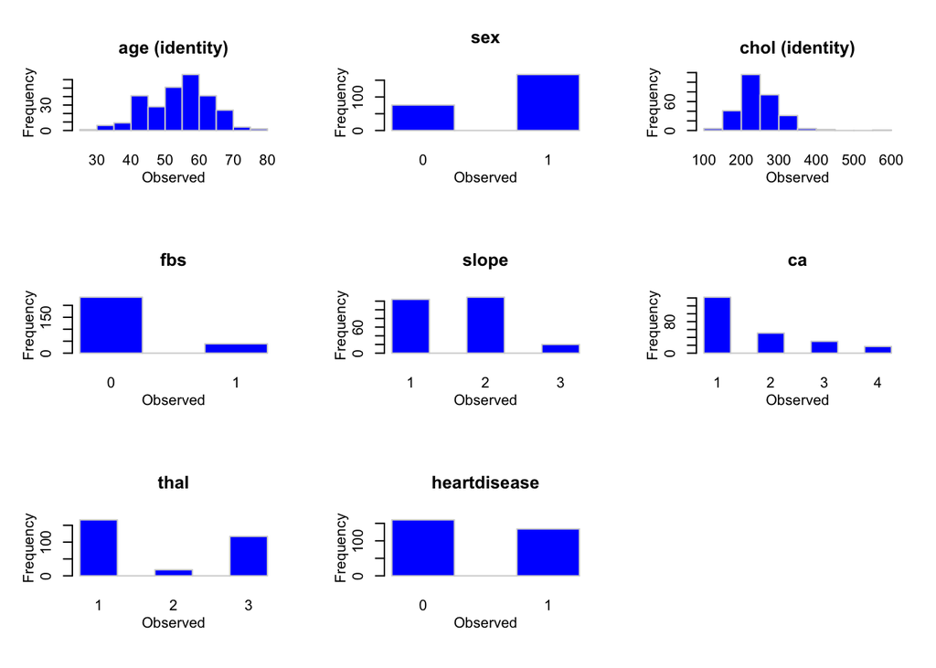

```r
hist(mdf)
```

## Imputations

```r
imputations <- mi(mdf, n.iter = 30, n.chains = 4, max.minutes = Inf, seed = NA,verbose = TRUE)
show(imputations)
```

```
## Object of class mi with 4 chains, each with 30 iterations.
## Each chain is the evolution of an object of missing_data.frame class with 303 observations on 14 variables.
```

Check for apporoximately constant mean across each feature (Looks good)

```r
mipply(imputations, mean, to.matrix = TRUE)
```

```
##                           chain:1      chain:2      chain:3      chain:4
## age                   54.56657658  54.40934325  54.40307713  54.28201043
## sex                    1.68316832   1.68976898   1.68646865   1.67656766
## cp                     3.15841584   3.15841584   3.15841584   3.15841584
## trestbps             131.68976898 131.68976898 131.68976898 131.68976898
## chol                 246.45009158 244.99901168 246.55081831 245.02196031
## fbs                    1.15181518   1.14191419   1.14191419   1.14191419
## restecg                1.99009901   1.99009901   1.99009901   1.99009901
## thalach              149.60726073 149.60726073 149.60726073 149.60726073
## exang                  1.32673267   1.32673267   1.32673267   1.32673267
## oldpeak                1.03960396   1.03960396   1.03960396   1.03960396
## slope                  1.63366337   1.61386139   1.61716172   1.63366337
## ca                     1.67656766   1.65346535   1.66006601   1.64026403
## thal                   1.83828383   1.83828383   1.83828383   1.83828383
## heartdisease           1.45544554   1.46204620   1.45874587   1.45874587
## missing_age            0.09900990   0.09900990   0.09900990   0.09900990
## missing_sex            0.19801980   0.19801980   0.19801980   0.19801980
## missing_chol           0.09900990   0.09900990   0.09900990   0.09900990
## missing_fbs            0.09900990   0.09900990   0.09900990   0.09900990
## missing_slope          0.09900990   0.09900990   0.09900990   0.09900990
## missing_ca             0.20792079   0.20792079   0.20792079   0.20792079
## missing_thal           0.00660066   0.00660066   0.00660066   0.00660066
## missing_heartdisease   0.02970297   0.02970297   0.02970297   0.02970297
```

Check for a convergence diagnostic near 1.

```r
Rhats(imputations)
```

```
##          mean_age          mean_sex         mean_chol          mean_fbs
##         1.0096378         0.9901078         0.9888149         1.0050248
##        mean_slope           mean_ca         mean_thal mean_heartdisease
##         1.0243364         1.0198296         1.0140852         0.9899378
##            sd_age            sd_sex           sd_chol            sd_fbs
##         1.0003464         0.9903772         0.9897925         1.0048010
##          sd_slope             sd_ca           sd_thal   sd_heartdisease
##         1.0194755         1.0001562         1.0143390         0.9894472
```

Run 5 more iterations

```r
imputations <- mi(imputations, n.iter = 5)
```

Visualize

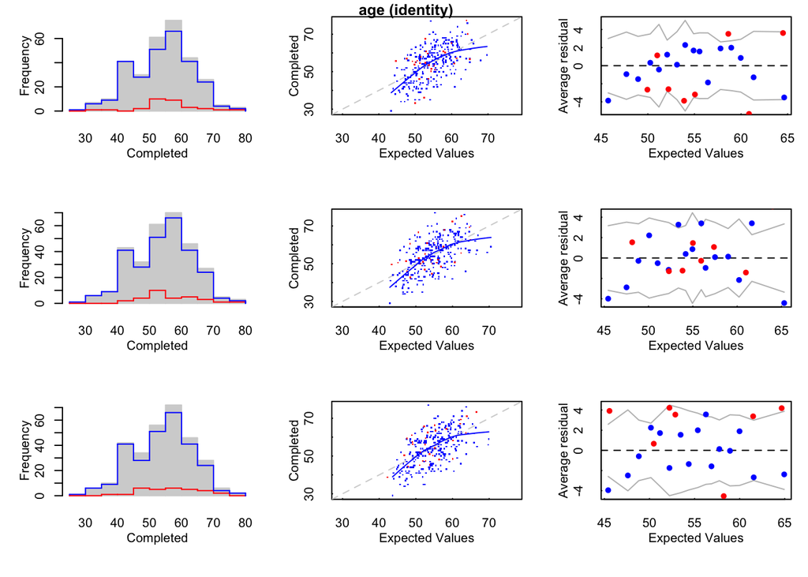

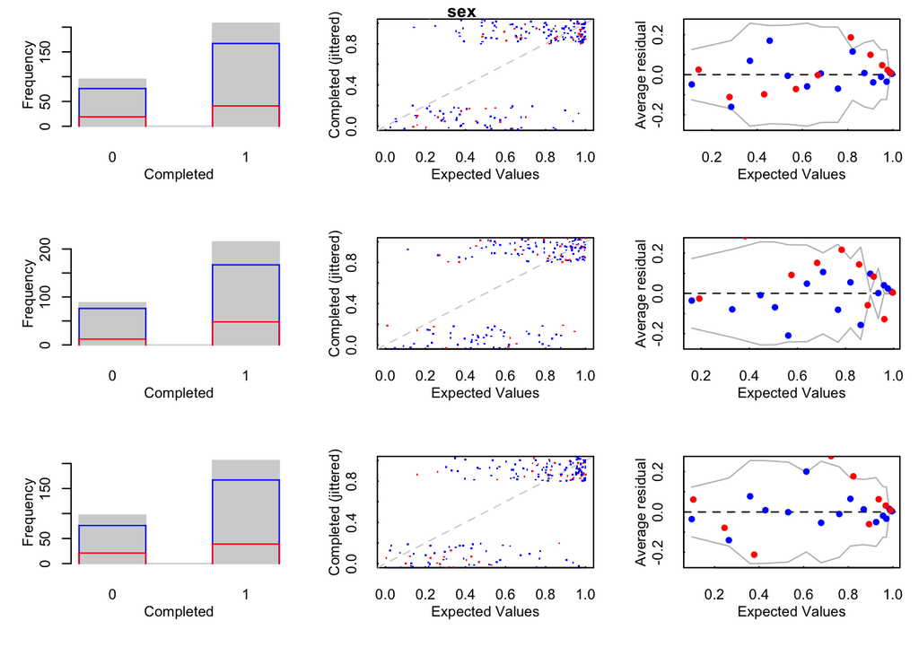

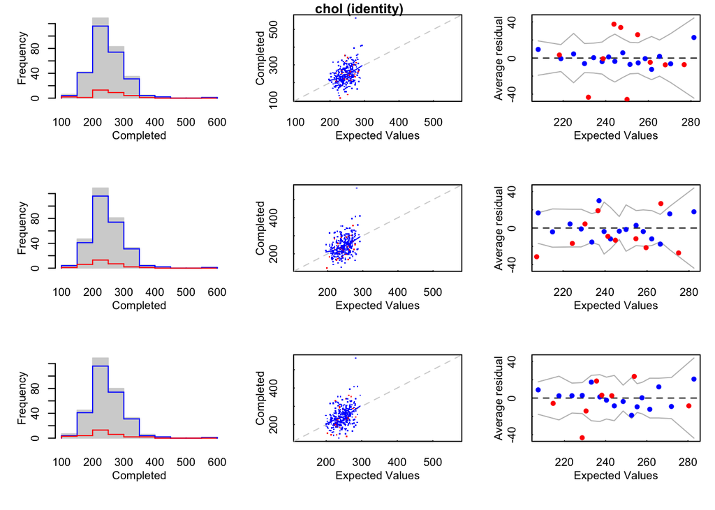

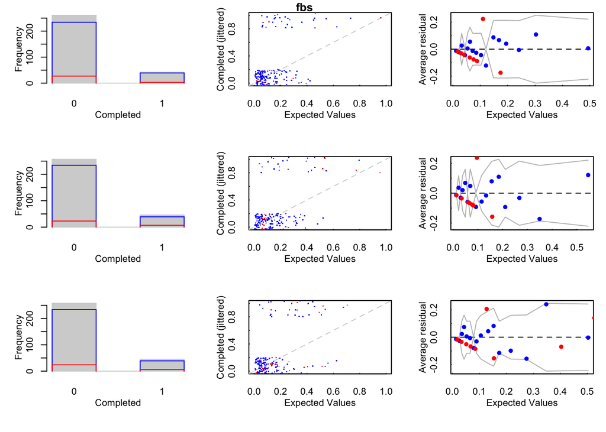

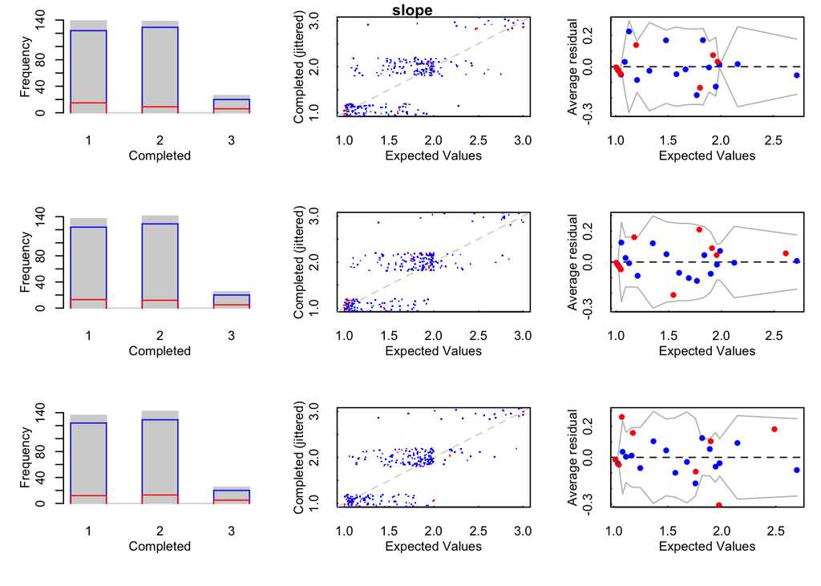

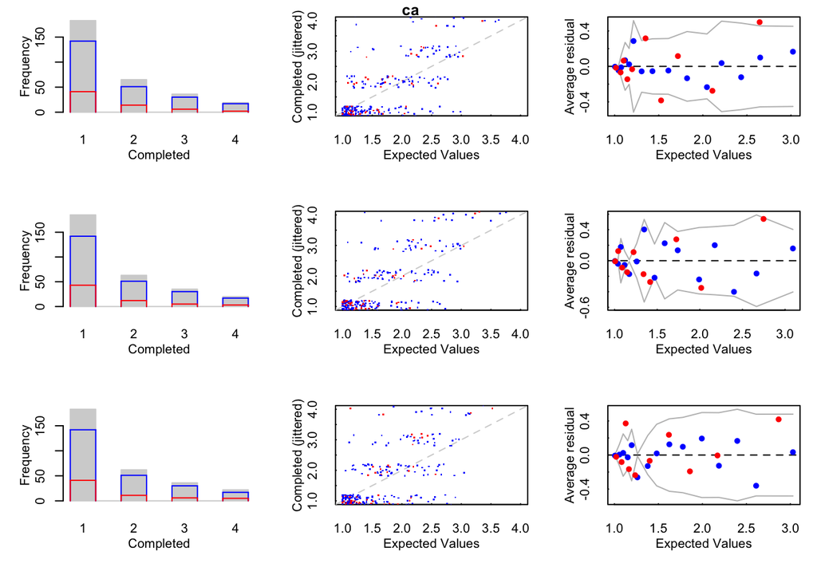

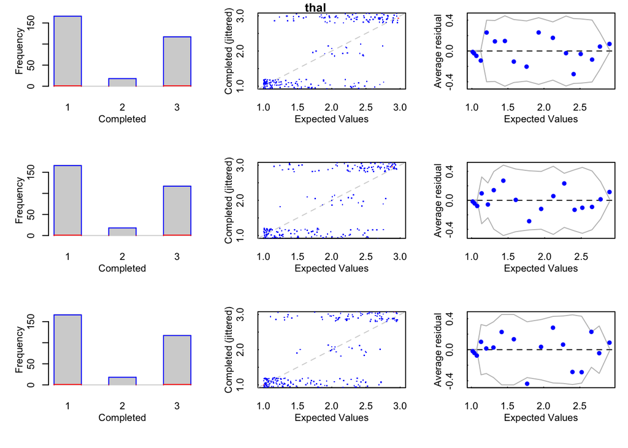

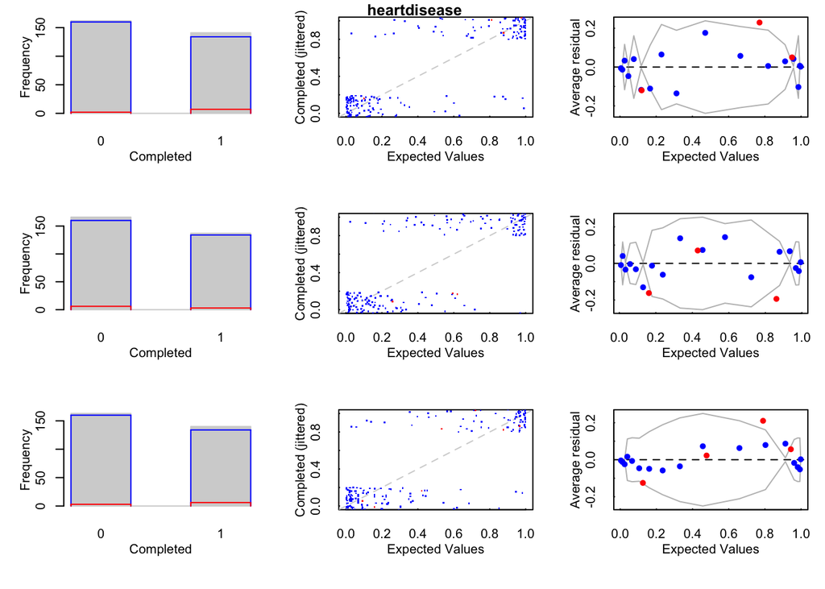

```r
plot(imputations)
```

Complete the data

```r
Data <- complete(imputations, m = 1)
str(Data)
```

```
## 'data.frame':    303 obs. of  22 variables:
##  $ age                 : num  63 67 67 37 41 56 62 57 63 53 ...
##  $ sex                 : Factor w/ 2 levels "0","1": 2 2 2 2 1 2 1 1 2 2 ...
##  $ cp                  : Factor w/ 4 levels "1","2","3","4": 1 4 4 3 2 2 4 4 4 4 ...
##  $ trestbps            : int  145 160 120 130 130 120 140 120 130 140 ...
##  $ chol                : num  233 213 229 250 204 ...
##  $ fbs                 : Factor w/ 2 levels "0","1": 2 1 1 1 1 1 1 1 1 2 ...
##  $ restecg             : Factor w/ 3 levels "0","1","2": 3 3 3 1 3 1 3 1 3 3 ...
##  $ thalach             : int  150 108 129 187 172 178 160 163 147 155 ...
##  $ exang               : Factor w/ 2 levels "0","1": 1 2 2 1 1 1 1 2 1 2 ...
##  $ oldpeak             : num  2.3 1.5 2.6 3.5 1.4 0.8 3.6 0.6 1.4 3.1 ...
##  $ slope               : Factor w/ 3 levels "1","2","3": 3 2 2 3 1 1 3 1 1 3 ...
##  $ ca                  : Factor w/ 4 levels "0","1","2","3": 1 4 3 1 1 1 3 1 2 1 ...
##  $ thal                : Factor w/ 3 levels "3","6","7": 2 1 3 1 1 1 1 1 3 3 ...
##  $ heartdisease        : Factor w/ 2 levels "0","1": 1 2 2 1 1 1 2 1 2 2 ...
##  $ missing_age         : logi  FALSE FALSE FALSE FALSE FALSE FALSE ...
##  $ missing_sex         : logi  FALSE FALSE FALSE FALSE FALSE FALSE ...
##  $ missing_chol        : logi  FALSE TRUE FALSE FALSE FALSE FALSE ...
##  $ missing_fbs         : logi  FALSE FALSE FALSE FALSE FALSE FALSE ...
##  $ missing_slope       : logi  FALSE FALSE FALSE FALSE FALSE FALSE ...
##  $ missing_ca          : logi  FALSE FALSE FALSE FALSE FALSE FALSE ...
##  $ missing_thal        : logi  FALSE FALSE FALSE FALSE FALSE FALSE ...
##  $ missing_heartdisease: logi  FALSE FALSE FALSE FALSE FALSE FALSE ...
```

```r
dim(na.omit(Data))
```

```
## [1] 303  22
```

We change the data into factors so we do not have to perform OHE like Python.

```r
ind <- c(2,3,6,7,9,11,12,13,14)

for (i in ind){
  Data[,i] <- as.factor(Data[,i])
}
```

## EDA for Quantitative Data

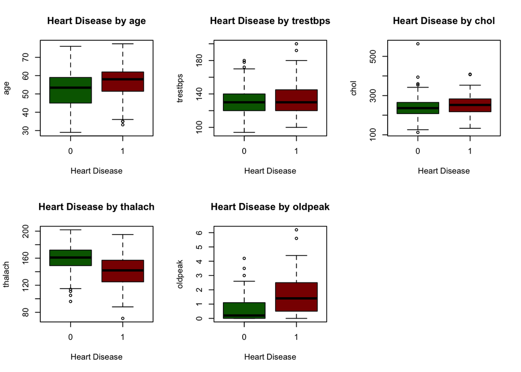

```r
par(mfrow = c(2,3))
boxplot(age~heartdisease, data = Data, col = c("darkgreen", "darkred"), main = "Heart Disease by age", xlab = "Heart Disease")
boxplot(trestbps~heartdisease, data = Data, col = c("darkgreen", "darkred"), main = "Heart Disease by trestbps", xlab = "Heart Disease") # Kinda different, not really
boxplot(chol~heartdisease, data = Data, col = c("darkgreen", "darkred"), main = "Heart Disease by chol", xlab = "Heart Disease") # Not very different
boxplot(thalach~heartdisease, data = Data, col = c("darkgreen", "darkred"), main = "Heart Disease by thalach", xlab = "Heart Disease")
boxplot(oldpeak~heartdisease, data = Data, col = c("darkgreen", "darkred"), main = "Heart Disease by oldpeak", xlab = "Heart Disease")
```

## EDA for Qualitative Data

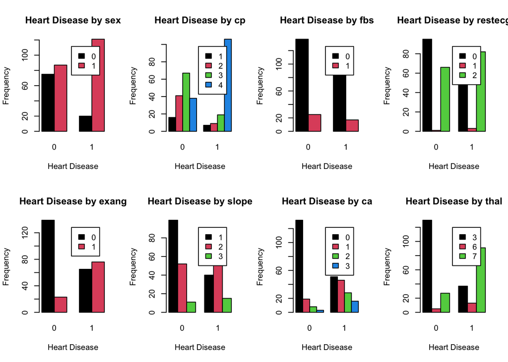

```r
par(mfrow = c(2, 4))
barplot(table(Data$sex, Data$heartdisease), legend.text = T, beside = T, main = "Heart Disease by sex", ylab = "Frequency", xlab = "Heart Disease", col=1:2) # Sex
barplot(table(Data$cp, Data$heartdisease), legend.text = T, beside = T, main = "Heart Disease by cp", ylab = "Frequency", xlab = "Heart Disease", col=1:4) # cp
barplot(table(Data$fbs, Data$heartdisease), legend.text = T, beside = T, main = "Heart Disease by fbs", ylab = "Frequency", xlab = "Heart Disease", col=1:2) #fbs (Not very different)
barplot(table(Data$restecg, Data$heartdisease), legend.text = T, beside = T, main = "Heart Disease by restecg", ylab = "Frequency", xlab = "Heart Disease", col=1:3) # restecg (Kinda different)
barplot(table(Data$exang, Data$heartdisease), legend.text = T, beside = T, main = "Heart Disease by exang", ylab = "Frequency", xlab = "Heart Disease", col=1:2) # exang
barplot(table(Data$slope, Data$heartdisease), legend.text = T, beside = T, main = "Heart Disease by slope", ylab = "Frequency", xlab = "Heart Disease", col=1:3) # slope
barplot(table(Data$ca, Data$heartdisease), legend.text = T, beside = T, main = "Heart Disease by ca", ylab = "Frequency", xlab = "Heart Disease", col=1:4) # ca
barplot(table(Data$thal, Data$heartdisease), legend.text = T, beside = T, main = "Heart Disease by thal", ylab = "Frequency", xlab = "Heart Disease", col=1:3) # thal
```

## Delete the unecessary varibles and split the data into test and train sets

```r
newdata <- Data[,-c(15:22)]
anyNA(newdata)
```

```
## [1] FALSE
```

```r
set.seed(4052)
test.ind <- sample(nrow(newdata), floor(nrow(newdata)*0.3))

train <- newdata[-test.ind,]
test <- newdata[test.ind,]
```

## Logistic Regression for Iterative Regression

```r
set.seed(1)
log.model <- glm(heartdisease~., data = train, family = binomial)
```

```r
a <- MASS::stepAIC(log.model, direction = "backward")
```

```
## Start:  AIC=157.65
## heartdisease ~ age + sex + cp + trestbps + chol + fbs + restecg +
##     thalach + exang + oldpeak + slope + ca + thal
##
##            Df Deviance    AIC
## - fbs       1   115.78 155.78
## - slope     2   118.15 156.15
## - trestbps  1   116.25 156.25
## - chol      1   116.60 156.60
## - oldpeak   1   116.88 156.88
## <none>          115.64 157.65
## - exang     1   118.38 158.38
## - restecg   2   122.15 160.15
## - age       1   120.46 160.46
## - thalach   1   121.81 161.81
## - thal      2   125.45 163.45
## - cp        3   129.95 165.95
## - sex       1   127.98 167.98
## - ca        3   152.54 188.54
##
## Step:  AIC=155.78
## heartdisease ~ age + sex + cp + trestbps + chol + restecg + thalach +
##     exang + oldpeak + slope + ca + thal
##
##            Df Deviance    AIC
## - trestbps  1   116.31 154.31
## - slope     2   118.49 154.49
## - chol      1   116.79 154.79
## - oldpeak   1   117.01 155.01
## <none>          115.78 155.78
## - exang     1   118.56 156.56
## - restecg   2   122.30 158.30
## - age       1   120.67 158.67
## - thalach   1   121.91 159.91
## - thal      2   125.57 161.57
## - cp        3   131.39 165.39
## - sex       1   128.83 166.83
## - ca        3   152.90 186.90
##
## Step:  AIC=154.31
```

[output cut: 34 more lines]

```
## Step:  AIC=151.95
## heartdisease ~ age + sex + cp + restecg + thalach + exang + oldpeak +
##     ca + thal
##
##           Df Deviance    AIC
## <none>         119.95 151.95
## - exang    1   122.54 152.54
## - age      1   122.98 152.98
## - thalach  1   126.57 156.57
## - oldpeak  1   126.61 156.61
## - restecg  2   129.16 157.16
## - thal     2   131.49 159.49
## - sex      1   129.59 159.59
## - cp       3   134.06 160.06
## - ca       3   156.19 182.19
```

```r
a$terms
```

```
## heartdisease ~ age + sex + cp + restecg + thalach + exang + oldpeak +
##     ca + thal
## attr(,"variables")
## list(heartdisease, age, sex, cp, restecg, thalach, exang, oldpeak,
##     ca, thal)
## attr(,"factors")
##              age sex cp restecg thalach exang oldpeak ca thal
## heartdisease   0   0  0       0       0     0       0  0    0
## age            1   0  0       0       0     0       0  0    0
## sex            0   1  0       0       0     0       0  0    0
## cp             0   0  1       0       0     0       0  0    0
## restecg        0   0  0       1       0     0       0  0    0
## thalach        0   0  0       0       1     0       0  0    0
## exang          0   0  0       0       0     1       0  0    0
## oldpeak        0   0  0       0       0     0       1  0    0
## ca             0   0  0       0       0     0       0  1    0
## thal           0   0  0       0       0     0       0  0    1
## attr(,"term.labels")
## [1] "age"     "sex"     "cp"      "restecg" "thalach" "exang"   "oldpeak"
## [8] "ca"      "thal"
## attr(,"order")
## [1] 1 1 1 1 1 1 1 1 1
## attr(,"intercept")
## [1] 1
## attr(,"response")
## [1] 1
## attr(,".Environment")
## <environment: R_GlobalEnv>
## attr(,"predvars")
## list(heartdisease, age, sex, cp, restecg, thalach, exang, oldpeak,
##     ca, thal)
## attr(,"dataClasses")
## heartdisease          age          sex           cp      restecg      thalach
##     "factor"    "numeric"     "factor"     "factor"     "factor"    "numeric"
##        exang      oldpeak           ca         thal
##     "factor"    "numeric"     "factor"     "factor"
```

```r
#Final model
log.model <- glm(a$terms, data = train, family = binomial)
```

```r
# Predicted probability of being in class
log.pred <- predict(log.model, newdata = test, type = "response")
log.class <- as.numeric(log.pred > 0.5)
# Confusion Matrix
(mat <- xtabs(~log.class + test$heartdisease))
```

```
##          test$heartdisease
## log.class  0  1
##         0 42 12
##         1  4 32
```

```r
# Error rate
(mat[1,2] + mat[2,1])/sum(mat)
```

```
## [1] 0.1777778
```

## ROC for Logisitc Regression (Iterative Regression Imputation)

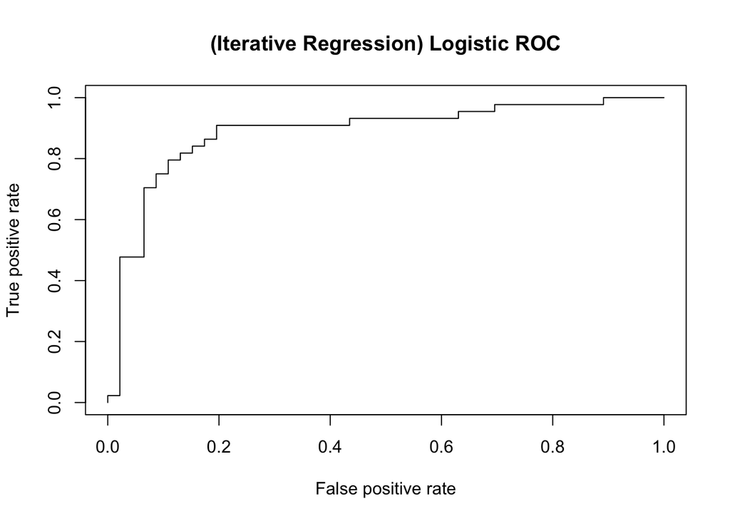

```r
set.seed(1)
log.pred <- predict(log.model, newdata = test)
pred <- prediction(predictions = log.pred, labels = test$heartdisease)

log.roc <- performance(pred, measure = "tpr", x.measure = "fpr")
plot(log.roc, main = "(Iterative Regression) Logistic ROC")
```

```r
log_perf2 <- performance(pred, measure = "auc")
log_perf2@y.values[[1]]
```

```
## [1] 0.8868577
```

## Random Forest Iterative Regression Imputation

```r
p <- ncol(train) - 1
k <- 5
ntree <- c(100, 200, 300, 400, 500, 600, 700, 800, 900, 1000)

n <- 1:p
tuningpar <- expand.grid(n, ntree)
cv.er.forest <- matrix(nrow = k, ncol = nrow(tuningpar))
```

## Cross Validation K-Fold Split

```r
set.seed(1)
obs.per.fold <- ceiling(nrow(train)/k)
shuffle.indices <- sample(nrow(train), nrow(train))
folds <- vector("list", length = k)
for (i in 1:k) {
  if (i != k) {
    fold.indices <- (i - 1)*obs.per.fold + 1:obs.per.fold
    folds[[i]] <- shuffle.indices[fold.indices]
  } else {
    fold.indices <- ((i - 1)*obs.per.fold + 1):nrow(train)
    folds[[i]] <- shuffle.indices[fold.indices]
  }
}
```

## Testing for the two hyper parameters, ntrees && mtry.

```r
set.seed(1)
for (i in 1:k) {
  cv.training <- train[-folds[[i]],]
  cv.validation <- train[folds[[i]],]
    for (j in 1:nrow(tuningpar)) {
      rf <- randomForest(x = cv.training[,-14], y = cv.training[,14], mtry = tuningpar[j,1],
      ntree = tuningpar[j,2])
      rfpred <- predict(rf, newdata = cv.validation[,-14])
      cv.er.forest[i,j] <- mean(rfpred != cv.validation[,14])
    }
}
meancv <- colMeans(cv.er.forest)
optimal <- tuningpar[which(meancv == min(meancv)),]
names(optimal) <- c("# of var sampled", "# of Trees")
optimal
```

```
##    # of var sampled # of Trees
## 4                 4        100
## 27                1        300
```

## Prediction based on the test case

```r
set.seed(1)
rand.forest <- randomForest(x = train[,-14], y = train[,14], mtry = 3, ntree = 500)

#Predicted probability of being in class
rand.pred <- predict(rand.forest, newdata = test[,-14], type = "prob")[,2]
```

## Random Forest Confusion Matrix

```r
rand.class <- predict(rand.forest, newdata = test[,-14], type = "response")
(mat <- xtabs(~rand.class + test$heartdisease))
```

```
##           test$heartdisease
## rand.class  0  1
##          0 42  9
##          1  4 35
```

```r
(mat[1,2]+mat[2,1])/sum(mat) # Error rate
```

```
## [1] 0.1444444
```

```r
importance(rand.forest)
```

```
##          MeanDecreaseGini
## age             7.6556519
## sex             3.7348212
## cp             14.9091276
## trestbps        7.8160017
## chol            8.4904734
## fbs             0.9113271
## restecg         3.2337336
## thalach        14.0218319
## exang           5.1429739
## oldpeak        11.1365208
## slope           3.2075612
## ca             12.8082787
## thal           11.0319380
```

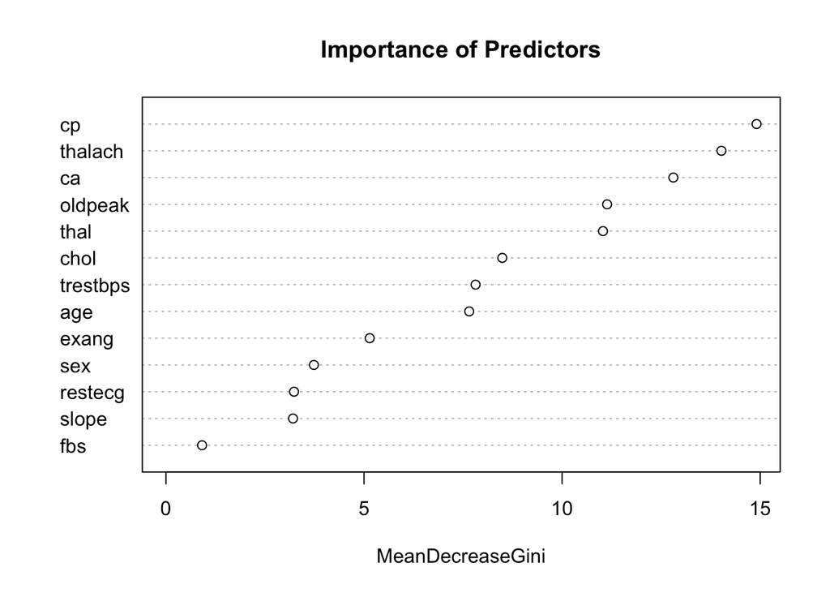

```r
varImpPlot(rand.forest, main = "Importance of Predictors")
```

## ROC Curve for Random Forest Iterative Regression Imputation

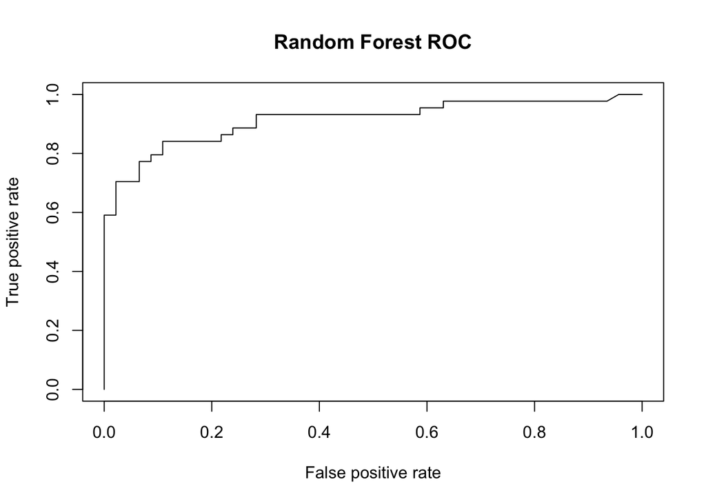

```r
pred <- prediction(predictions = rand.pred, labels = test$heartdisease)

rand.roc <- performance(pred, measure = "tpr", x.measure = "fpr")
plot(rand.roc, main = "Random Forest ROC")
```

## AUC for Random Forest Iterative Regression Imputation

```r
log_perf2 <- performance(pred, measure = "auc")
log_perf2@y.values[[1]]
```

```
## [1] 0.9137846
```

## Support Vector Machine

```r
set.seed(1)
tune.out <- tune(svm, heartdisease~., data = train,ranges = list(cost = c(0.001, 0.01, 0.1, 1, 10, 100), degree = c(1,2,3), kernel = c("polynomial", "linear", "radial")))
summary(tune.out)
```

```
##
## Parameter tuning of 'svm':
##
## - sampling method: 10-fold cross validation
##
## - best parameters:
##  cost degree kernel
##   100      1 linear
##
## - best performance: 0.1506494
##
## - Detailed performance results:
##     cost degree     kernel     error dispersion
## 1  1e-03      1 polynomial 0.4556277 0.11606635
## 2  1e-02      1 polynomial 0.4556277 0.11606635
```

[output cut: 52 more lines]

```r
best <- summary(tune.out)$best.model
```

```r
svm.pred <- predict(best, newdata = test)
(mat <- xtabs(~svm.pred + test$heartdisease))
```

```
##         test$heartdisease
## svm.pred  0  1
##        0 43 13
##        1  3 31
```

```r
(mat[1,2] + mat[2,1])/sum(mat)
```

```
## [1] 0.1777778
```

About 17.78%

## ROC for Support Vector Machine

```r
#Create the function
rocplot<-function(predi,truth,...){
predob<-prediction(predi,truth)
perf<-performance(predob,"tpr","fpr")
plot(perf,...)
}
```

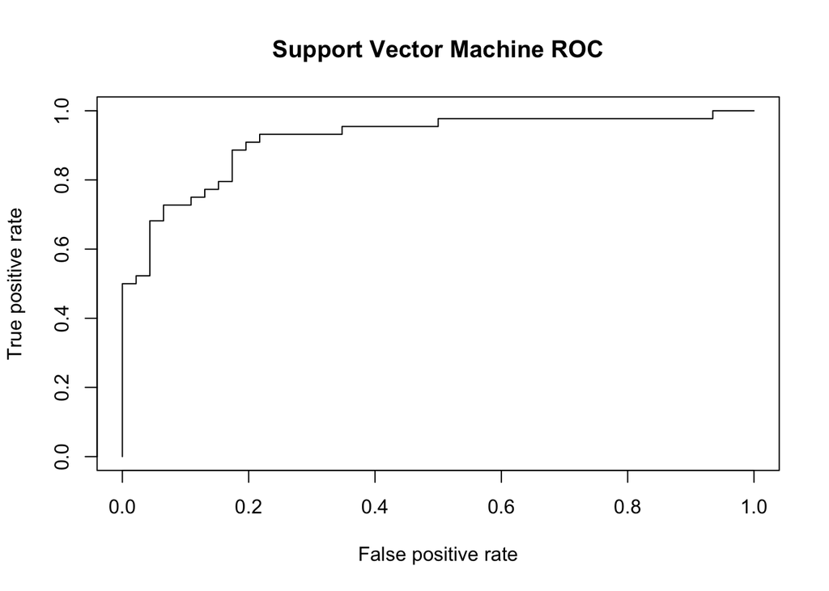

```r
# Obtain the fitted values
svm.fit <- svm(heartdisease~., data = train, kernel = "polynomial", degree = 1, cost = 1, decision.values=TRUE)
fitted <- attributes(predict(svm.fit, newdata = test, decision.values=TRUE))$decision.values
rocplot(-fitted, test$heartdisease, main = "Support Vector Machine ROC")
```

## AUC

```r
svm.fit <- svm(heartdisease~., data = train, kernel = "polynomial", degree = 1, cost = 1, probability=TRUE)
prob <- attributes(predict(svm.fit, newdata = test, probability =TRUE))$probabilities[,2]

predictionsvm <- prediction(prob,test$heartdisease)
svm_perf2 <- performance(predictionsvm, measure = "auc")
svm_perf2@y.values[[1]]
```

```
## [1] 0.9150198
```

About 92%